# Selection in maize: Tajima's D and PBS from genotype likelihoods

**Purpose.** Domestication is a selection experiment run by people over thousands of years, and maize is the textbook case. This exercise looks for its signature two ways: a shift in the **site frequency spectrum** measured by Tajima's *D*, and population differentiation measured by **PBS**. Everything is computed with ANGSD from **genotype likelihoods**, never from called genotypes, because the sequencing is low depth.

**What you will do**

**The data.** **Maize and its wild relatives** (*Zea mays*), 50 low-depth BAMs:

[output not shown]

The genotypes are **not called** — the exercise works from site allele frequency likelihoods (SAF). At this depth calling a genotype would bias the SFS exactly where Tajima's *D* reads it, which is the reason for the whole approach.

Two reference genomes are supplied: **B73** (the domesticated maize reference) and **TDD39103** (a *parviglumis* assembly).

**Note.** The ANGSD steps that produce the SAF files take 15+ minutes, so they are shown but left commented out, with the results provided.

**Before this** do SFS, Fst and PBS, which introduces the same statistics on human data.

## Setup

All the paths used by this exercise are set in the cell below.

```
#############################################################
# ALL PATHS ARE SET HERE
# If the data moves, this is the ONLY cell you need to change.
# No cell below this one uses a full path.
#############################################################

# where the shared data lives
DATA=/course/data/current_data/selection/maize

# where you will do the exercise
WORK_DIR=$HOME/selection_maize

mkdir -p $WORK_DIR
echo $WORK_DIR > $HOME/.selection_maize_workdir
cd $WORK_DIR

# link the input files into the working folder
cp -sf $DATA/B73v3_25.fa.gz* .
cp -sf $DATA/TDD39103.fa.gz* .
cp -r -sf $DATA/res .
cp -r -sf $DATA/Figures .
cp -r -sf $DATA/bamfiles .

echo --programs that are installed:--
which angsd
which realSFS
which thetaStat

echo; echo --- files in folder ---
ls
```

```
# the working directory was set in the first cell of the notebook
work_d <- readLines(path.expand("~/.selection_maize_workdir"))[1]
setwd(work_d)
getwd()
```

'/davidData/data/course/.nbrender_home/selection_maize'

### Estimating Tajima's D in domesticated maize

For this exercise we will use 15 domesticated maize genomes from different varieties to look for signatures of selection that the domestication process might have left. For this, we have 15 BAM files with sequencing data for maize chromosome 4:

```
#Go to the working directory where we have the data:

# make links to files and add them to the folder
cp -r -sf  ${DATA_PATH}/bamfiles .
cp -sf ${DATA_PATH}/*fa.gz .
cp -sf ${DATA_PATH}/*fai .

#You can check which files we have in this directory by typing 'ls':
#list of BAM files with domesticated maize data:
echo -e "\n-- files in folder "
ls

echo -e "\n-- files in bamfiles folder "
ls bamfiles
```

```
cp: cannot stat '/bamfiles': No such file or directory
cp: cannot stat '/*fa.gz': No such file or directory
cp: cannot stat '/*fai': No such file or directory

-- files in folder
B73v3_25.fa.gz	    bamfiles  TDD39103.fa.gz
B73v3_25.fa.gz.fai  Figures   TDD39103.fa.gz.fai
B73v3_25.fa.gz.gzi  res       TDD39103.fa.gz.gzi

-- files in bamfiles folder
Ozarks_203_chr9.bam	 RIMMA0626.bam		    TIL16_chr9.bam
Ozarks_203_chr9.bam.bai  RIMMA0626.bam.bai	    TIL16_chr9.bam.bai
Ozarks_204_chr9.bam	 RIMMA0670.bam		    TIL17_chr9.bam
Ozarks_204_chr9.bam.bai  RIMMA0670.bam.bai	    TIL17_chr9.bam.bai
Ozarks_211_chr9.bam	 RIMMA0672.bam		    TIL2A_chr9.bam
Ozarks_211_chr9.bam.bai  RIMMA0672.bam.bai	    TIL2A_chr9.bam.bai
Ozarks_212_chr9.bam	 RIMMA0677.bam		    TIL2B_chr9.bam
Ozarks_212_chr9.bam.bai  RIMMA0677.bam.bai	    TIL2B_chr9.bam.bai
Ozarks_214_chr9.bam	 RIMMA1007.bam		    TIL2C_chr9.bam
Ozarks_214_chr9.bam.bai  RIMMA1007.bam.bai	    TIL2C_chr9.bam.bai
Ozarks_215_chr9.bam	 RIMMA1008.bam		    TIL2D_chr9.bam
Ozarks_215_chr9.bam.bai  RIMMA1008.bam.bai	    TIL2D_chr9.bam.bai
Ozarks_220_chr9.bam	 RIMMA1012.bam		    Tularosa_107_chr9.bam
Ozarks_220_chr9.bam.bai  RIMMA1012.bam.bai	    Tularosa_107_chr9.bam.bai
Ozarks_224_chr9.bam	 TIL01_chr9.bam		    Tularosa_109_chr9.bam
Ozarks_224_chr9.bam.bai  TIL01_chr9.bam.bai	    Tularosa_109_chr9.bam.bai
Ozarks_226_chr9.bam	 TIL02_chr9.bam		    Tularosa_110_chr9.bam
Ozarks_226_chr9.bam.bai  TIL02_chr9.bam.bai	    Tularosa_110_chr9.bam.bai
RIMMA0383.bam		 TIL04-TIP454_chr9.bam	    Tularosa_111_chr9.bam
RIMMA0383.bam.bai	 TIL04-TIP454_chr9.bam.bai  Tularosa_111_chr9.bam.bai
RIMMA0384.bam		 TIL07_chr9.bam		    Tularosa_112_chr9.bam
RIMMA0384.bam.bai	 TIL07_chr9.bam.bai	    Tularosa_112_chr9.bam.bai
RIMMA0385.bam		 TIL09_chr9.bam		    Tularosa_118_chr9.bam
RIMMA0385.bam.bai	 TIL09_chr9.bam.bai	    Tularosa_118_chr9.bam.bai
RIMMA0387.bam		 TIL10_chr9.bam		    Tularosa_121_chr9.bam
RIMMA0387.bam.bai	 TIL10_chr9.bam.bai	    Tularosa_121_chr9.bam.bai
RIMMA0415.bam		 TIL11_chr9.bam		    Tularosa_124_chr9.bam
RIMMA0415.bam.bai	 TIL11_chr9.bam.bai	    Tularosa_124_chr9.bam.bai
RIMMA0421.bam		 TIL12_chr9.bam		    Tularosa_132_chr9.bam
RIMMA0421.bam.bai	 TIL12_chr9.bam.bai	    Tularosa_132_chr9.bam.bai
RIMMA0623.bam		 TIL14_chr9.bam		    Tularosa_146_chr9.bam
RIMMA0623.bam.bai	 TIL14_chr9.bam.bai	    Tularosa_146_chr9.bam.bai
RIMMA0625.bam		 TIL15_chr9.bam
RIMMA0625.bam.bai	 TIL15_chr9.bam.bai
```

**Question**

- The reference genomes are linked in here: B73 for domesticated maize and TDD39103 for the wild relative. Why does it matter which one you map or call against?

Now, let's create a list with the BAM files that we will be using:

```
#All the modern maize BAM files start with 'RIM'
ls bamfiles/RIM*.bam > DomesticatedMaize.txt

echo -e "\b first lines of file"
head DomesticatedMaize.txt
```

```
 first lines of file
bamfiles/RIMMA0383.bam
bamfiles/RIMMA0384.bam
bamfiles/RIMMA0385.bam
bamfiles/RIMMA0387.bam
bamfiles/RIMMA0415.bam
bamfiles/RIMMA0421.bam
bamfiles/RIMMA0623.bam
bamfiles/RIMMA0625.bam
bamfiles/RIMMA0626.bam
bamfiles/RIMMA0670.bam
```

**Question**

- This builds a list of BAM files for one population. Why does ANGSD take a list of BAMs rather than called genotypes?

#### 1. Estimate Genotype-likelihoods (GL)

Now we can estimate GL using ANGSD -doSaf:

```
# do not run
# command takes to long (~Min)
# you can run it after class if you want
#angsd -bam DomesticatedMaize.txt \
#    -ref B73v3_25.fa.gz \
#    -anc TDD39103.fa.gz \
#    -out maize_chr4 \
#    -doSaf 1 \
#    -C 50 -baq 1 \
#    -GL 2 \
#    -P 5 \
#    -minMapQ 30 \
#    -minQ 20 \
#    -minInd 10 \
#    -setMinDepth 3 \
#    -doCounts 1 \
#    -r 4:1-242029974
```

**Question**

Check which parameters we are using and make sure they make sense to you.

This step takes too long to run so wecopy the results from the **res** directory like this (ANGSD outputs three files: maize_chr4.saf.gz, maize_chr4.saf.pos.gz and maize_chr4.saf.idx):

```
# copy results of the command and print the log
cp $DATA/res/maize_chr4* .
cat maize_chr4.log
```

[output not shown]

**Questions**

- `realSFS` estimates the site frequency spectrum from the SAF files. What is the hidden variable it is integrating over?
- Look at the shape of the SFS: is there an excess of rare variants?

#### 2. Estimate the SFS using realSFS

We will use realSFS to obtain an estimate of the SFS for domesticated maize. Note that we are providing realSFS the file that ends in *.idx*, which is the index for the GL that we generated before:

```
realSFS maize_chr4.saf.idx > maize_chr4.sfs
```

```
[persaf::persaf_init] Version of maize_chr4.saf.idx is 3
[persaf::persaf_init] Assuming .saf.gz file is maize_chr4.saf.gz
[persaf::persaf_init] Assuming .saf.pos.gz file is maize_chr4.saf.pos.gz
	-> args: tole:0.000000 nthreads:4 maxiter:100 nsites(block):0 start:(null) chr:(null) start:-1 stop:-1 fstout:(null) oldout:0 seed:-1 bootstrap:0 resample_chr:0 whichFst:0 fold:0 ref:(null) anc:(null)
	-> The choice of -nSites will require atleast: 119.419891 megabyte memory, that is at least: 0.03% of total memory
	-> dim(maize_chr4.saf.idx):31
	-> Dimension of parameter space: 31
	-> Done reading data from chromosome will prepare next chromosome
	-> Is in multi sfs, will now read data from chr:4
	-> hello Im the master merge part of realSFS. and I'll now do a tripple bypass to find intersect
	-> 1) Will set iter according to chooseChr and start and stop, and possibly using -sites
	-> Will run optimization on nSites: 3522027
------------
startlik=-11903056.791178
lik[2]=-964882.031557 diff=1.093817e+07 alpha:1.000000 sr2:8.001172e-01 nsites_difference[0]: 3.349383e+06
lik[5]=-963240.492718 diff=1.641539e+03 alpha:1.115581 sr2:9.366534e-06 nsites_difference[1]: 9.144228e+03
lik[8]=-963239.136837 diff=1.355881e+00 alpha:1.921925 sr2:1.402234e-10 nsites_difference[15]: 6.122965e+01
lik[11]=-963239.009903 diff=1.269347e-01 alpha:4.000000 sr2:4.664378e-12 nsites_difference[15]: 2.197188e+01
lik[14]=-963239.009286 diff=6.167521e-04 alpha:1.588629 sr2:8.801880e-14 nsites_difference[14]: 9.628027e-01
lik[17]=-963239.009148 diff=1.378724e-04 alpha:5.823317 sr2:4.720743e-15 nsites_difference[14]: 7.468488e-01
lik[20]=-963239.009148 diff=1.909211e-07 alpha:1.381122 sr2:3.786057e-17 nsites_difference[1]: 1.963713e-02
lik[23]=-963239.009148 diff=5.518086e-08 alpha:3.049772 sr2:2.131813e-19 nsites_difference[15]: 2.591782e-03
	-> Breaking EM(sr2) at iter:24, sqrt(sr2):1.675970e-11
likelihood: -963239.009148
------------
	-> Only read nSites: 0 will therefore prepare next chromosome (or exit)

	-> NB output is no longer log probs of the frequency spectrum!
	-> Output is now simply the expected values!
	-> You can convert to the old format simply with log(norm(x))

	-> Please check that it has converged!
	-> You can add start new optimization by supplying -sfs FILE, where is >FILE from this run
	-> -maxIter INT -tole FLOAT
```

**Question**

- This estimates the SFS for one population. Why is the SFS the thing Tajima's D is read from?

Now we will use R to plot the SFS, just to make sure it looks reasonable.

```
#read the file with the SFS:
sfsmaize<-scan('maize_chr4.sfs')

#exclude first column and normalise
sfsmaize<-sfsmaize[-c(1,length(sfsmaize))]
sfsmaize<-sfsmaize/sum(sfsmaize)

#create a PDF with the plot (you can also run the barplot line only)
pdf('chr4_sfs.pdf')
barplot(sfsmaize, names=1:length(sfsmaize), main='SFS chr4 maize')
dev.off()

barplot(sfsmaize, names=1:length(sfsmaize), main='SFS chr4 maize')
```

**agg_record_1861548291:** 2

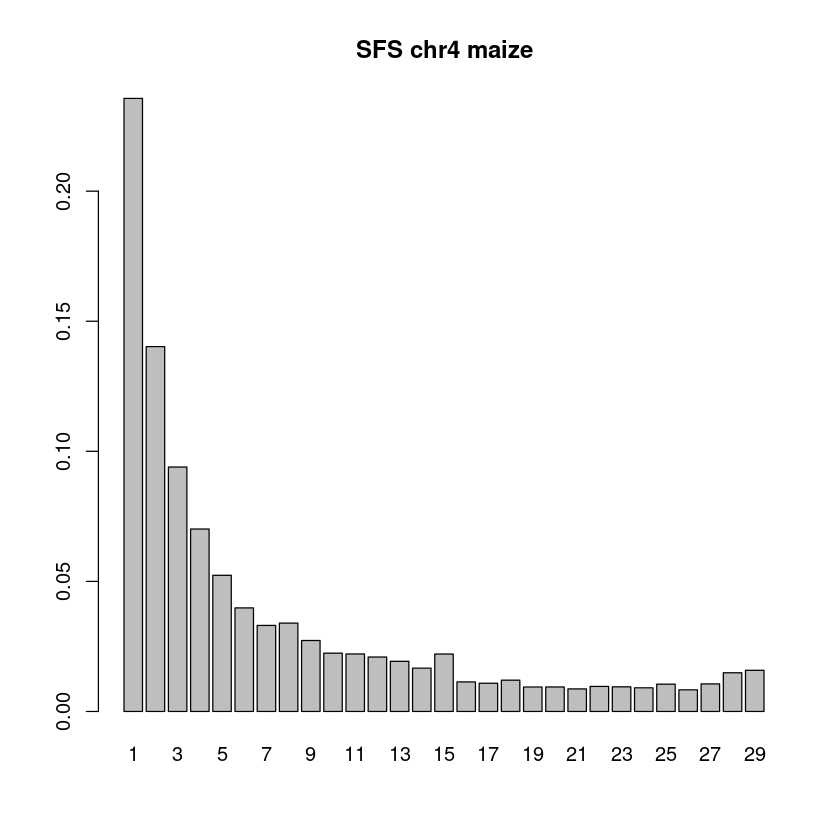

```
Read 31 items
```

**Questions**

- Tajima's *D* compares two estimates of theta. What does a negative value mean, and what does a positive one mean?
- Where along chromosome 4 is *D* most negative?

- What factors do you think could affect our SFS?
- What do you think we should consider when deciding which individuals/samples to include in our population?

#### 3. Calculate thetas per site

We will now use **realSFS saf2theta** to get the two diversity metrics that we need to estimate Tajima's D: theta and Pi.

```
#this might take a few minutes, so wait until it is done running:
realSFS saf2theta maize_chr4.saf.idx  \
    -sfs maize_chr4.sfs \
    -outname maize_chr4
```

```
[persaf::persaf_init] Version of maize_chr4.saf.idx is 3
[persaf::persaf_init] Assuming .saf.gz file is maize_chr4.saf.gz
[persaf::persaf_init] Assuming .saf.pos.gz file is maize_chr4.saf.pos.gz
	-> args: tole:0.000000 nthreads:4 maxiter:100 nsites(block):0 start:maize_chr4.sfs chr:(null) start:-1 stop:-1 fstout:maize_chr4 oldout:0 seed:-1 bootstrap:0 resample_chr:0 whichFst:0 fold:0 ref:(null) anc:(null)
	-> Will read chunks of size: 4096
	-> Reading: maize_chr4.sfs assuming counts (will normalize to probs internally)
	-> nChr:30
	-> Done reading data from chromosome will prepare next chromosome
	-> Is in multi sfs, will now read data from chr:4
	-> hello Im the master merge part of realSFS. and I'll now do a tripple bypass to find intersect
	-> 1) Will set iter according to chooseChr and start and stop, and possibly using -sites
	-> Only read nSites: 0 will therefore prepare next chromosome (or exit)
	-> Done reading data from chromosome will prepare next chromosome
	-> Writing 3522027 sites for chr:4
	-> Output filenames:
		->"maize_chr4.thetas.gz"
		->"maize_chr4.thetas.idx"
```

**Question**

- `realSFS` is estimating the spectrum. Is there an excess of rare variants, and would you expect that from domestication?

#### 4. Estimate Tajima's D

Now we will use **thetaStat** to estimate Tajima's D in 5Kb windows along chr4:

```
thetaStat do_stat \
    maize_chr4.thetas.idx \
    -win 5000 \
    -step 1000 \
    -outnames maize_chr4.thetas.5kWind
```

```
 thetaStat do_stat maize_chr4.thetas.idx -win 5000 -step 1000 -outnames maize_chr4.thetas.5kWind
	Assuming binfile:maize_chr4.thetas.gz and indexfile:maize_chr4.thetas.idx
		Information from index file:
		0	4	3522027	8	30
	 -r=(null) outnames=maize_chr4.thetas.5kWind step: 1000 win: 5000
	pc.chr=4 pc.nSites=3522027 firstpos=30555 lastpos=241908510
	Dumping file: "maize_chr4.thetas.5kWind.pestPG"
```

**Questions**

Once it is done running, let's look at the results:

```
head -n 5 maize_chr4.thetas.5kWind.pestPG
```

```
#(indexStart,indexStop)(firstPos_withData,lastPos_withData)(WinStart,WinStop)	Chr	WinCenter	tW	tP	tF	tH	tL	Tajima	fuf	fud	fayh	zeng	nSites
(159,1782)(31078,108833)(31000,36000)	4	33500	6.763158	4.250631	11.976197	8.510986	6.380808	-1.330410	-1.733252	-1.481226	-0.530547	-0.048605	1623
(285,1782)(32697,108833)(32000,37000)	4	34500	5.999502	3.978113	9.966828	8.490016	6.234064	-1.194047	-1.483449	-1.240701	-0.630713	0.033371	1497
(377,1782)(33043,108833)(33000,38000)	4	35500	5.991736	3.976013	9.938799	8.486015	6.231014	-1.192101	-1.478595	-1.235632	-0.631234	0.034083	1405
(1110,1782)(34000,108833)(34000,39000)	4	36500	3.426512	2.982402	3.904624	6.463406	4.722904	-0.430669	-0.354815	-0.228656	-0.829054	0.308509	672
```

Can you guess what each column is?

#### Plot the results in R

```
#read the table with the results from thetaStat:
d<-read.table('maize_chr4.thetas.5kWind.pestPG', as.is=T, h=T, comment.char='')

#exclude results that are NaN due to missing data:
d<-d[!is.na(d$fuf),]

#exclude windows with less than 100 SNPs:
d<-d[d$nSites>=100,]

#identify the 0.1% windows with the most negative Tajima's D
perc01<-sort(d$Tajima)[length(d$Tajima)*0.001]

#plot the Tajima's D vs the position along chr4:
pdf('TajimasD_5Kwin.pdf', useDingbats=F, width=7.5, heigh=5)

plot(as.numeric(d$WinCenter), d$Tajima, col='grey80', ylab='Tajima D',  xlab='Chr9', pch=16)

#draw a line to mark the location of bt2 gene
abline(v=c(58979526, 58985686), col='purple')

#draw a line to mark the 0.1% most negative D
abline(h=perc01, col='red', lty=2)
dev.off()

plot(as.numeric(d$WinCenter), d$Tajima, col='grey80', ylab='Tajima D',  xlab='Chr9', pch=16)

#draw a line to mark the location of bt2 gene
abline(v=c(58979526, 58985686), col='purple')

#draw a line to mark the 0.1% most negative D
abline(h=perc01, col='red', lty=2)
```

**agg_record_1988409286:** 2

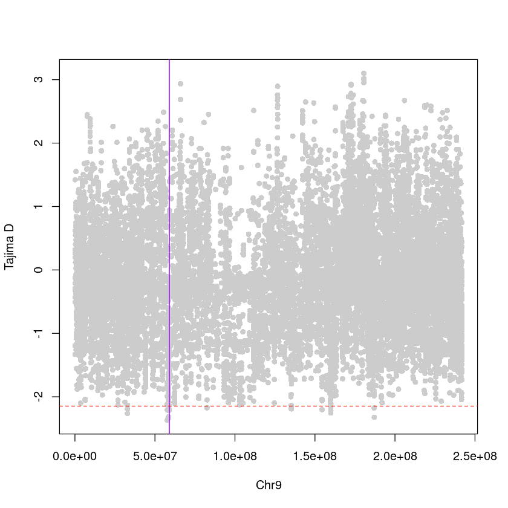

### Population Branch Statistic (PBS)

Now we will look for selection specificially in a population of ancient maize in Eastern North America (ENA). We would like to know if there has been any selection in the evolutionary lineage that gave rise to maize in ENA. We know that maize dispersed north from the domestication center reaching the US Southwest (US SW) ~4000 years ago, and then moved into ENA between 2000-1000 years ago (Figure below,left side).

So, for this exercise we will use genomic data from three populations:

- 9 genomes from the Ozarks rockshelters in ENA
- 10 genomes from the Tularosa cave in the US SW
- 16 genomes from maize's wild ancestor *Zea mays* subsp. *parviglumis* So, given how these populations are related, we want to setup a PBS test like the one in the figure below (left side)

[figure not shown]

#### 0. Prepare input files

Start by creating a list of BAM files for each population:

```
#Ozarks maize:
ls bamfiles/Ozark*.bam >ozarks.txt

#US SW maize:
ls bamfiles/Tularosa*.bam >SW750.txt

#wild maize:
ls bamfiles/TIL*.bam >parviglumis.txt
```

**Question**

#### 1. Estimate GL for each population

Now let's estimate GL for each population independently using ANGSD (we will restrict to chr9 so that it is faster to run). Run one by one (it will take a couple of minutes each):

```
#### takes around 15 min to run all 3. So lets just copy the results
# US Southwest:
#angsd -bam SW750.txt -ref B73v3_25.fa.gz -anc TDD39103.fa.gz -out sw750_ds1 -doSaf 1 -C 50 -baq 1 -GL 2 -minMapQ 30 -minQ 20 -minInd 6 -setMinDepth 3 -doCounts 1  -r 9:1-157021084 &

# Ozarks (Eastern North America):
#angsd -bam ozarks.txt -ref B73v3_25.fa.gz -anc TDD39103.fa.gz -out ozark_ds1 -doSaf 1 -C 50 -baq 1 -GL 2 -minMapQ 30 -minQ 20 -minInd 6 -setMinDepth 3 -doCounts 1  -r 9:1-157021084 &

# Wild maize (parviglumis):
#angsd -bam parviglumis.txt -ref B73v3_25.fa.gz -anc TDD39103.fa.gz -out parviglumis_ds1 -doSaf 1 -C 50 -baq 1 -GL 2 -minMapQ 30 -minQ 20 -minInd 6 -setMinDepth 3 -doCounts 1  -r 9:1-157021084



## The he restart the kernal and copy results to your folder instead
 cp $DATA/res/*ds1* .
 ls *ds1*
```

```
ozark_ds1.arg	      parviglumis_ds1.arg	  sw750_ds1.arg
ozark_ds1.saf.gz      parviglumis_ds1.saf.gz	  sw750_ds1.saf.gz
ozark_ds1.saf.idx     parviglumis_ds1.saf.idx	  sw750_ds1.saf.idx
ozark_ds1.saf.pos.gz  parviglumis_ds1.saf.pos.gz  sw750_ds1.saf.pos.gz
```

Check again the parameters, do they make sense to you?

#### 2. Estimate 2D-SFS

We now need to estimate the 2-dimension SFS for every combination of 2 populations (again, run one at a time):

```
# parviglumis X US SW:
realSFS parviglumis_ds1.saf.idx sw750_ds1.saf.idx > parviglumis_sw750.sfs

# parviglumis X Ozarks:
realSFS parviglumis_ds1.saf.idx ozark_ds1.saf.idx > parviglumis_ozark.sfs

# Ozarks X US SW:
realSFS ozark_ds1.saf.idx sw750_ds1.saf.idx > ozark_sw750.sfs
```

```
[persaf::persaf_init] Version of parviglumis_ds1.saf.idx is 3
[persaf::persaf_init] Assuming .saf.gz file is parviglumis_ds1.saf.gz
[persaf::persaf_init] Assuming .saf.pos.gz file is parviglumis_ds1.saf.pos.gz
[persaf::persaf_init] Version of sw750_ds1.saf.idx is 3
[persaf::persaf_init] Assuming .saf.gz file is sw750_ds1.saf.gz
[persaf::persaf_init] Assuming .saf.pos.gz file is sw750_ds1.saf.pos.gz
	-> args: tole:0.000000 nthreads:4 maxiter:100 nsites(block):0 start:(null) chr:(null) start:-1 stop:-1 fstout:(null) oldout:0 seed:-1 bootstrap:0 resample_chr:0 whichFst:0 fold:0 ref:(null) anc:(null)
[main] Multi SFS is 'still' under development. Please report strange behaviour.
	-> The choice of -nSites will require atleast: 328.087921 megabyte memory, that is at least: 0.08% of total memory
	-> dim(parviglumis_ds1.saf.idx):33
	-> dim(sw750_ds1.saf.idx):21
	-> Dimension of parameter space: 693
	-> Done reading data from chromosome will prepare next chromosome
	-> Is in multi sfs, will now read data from chr:9
	-> hello Im the master merge part of realSFS. and I'll now do a tripple bypass to find intersect
	-> 1) Will set iter according to chooseChr and start and stop, and possibly using -sites
	-> Sites to keep[9] from pop0:	38471
	-> Sites to keep[9] from pop1:	38471
	-> [readdata] lastread:38471 posi:564186
	-> Comparing positions: 1 with 0 has:38471
	-> Only read nSites: 38471 will therefore prepare next chromosome (or exit)
	-> Done reading data from chromosome will prepare next chromosome
	-> Will run optimization on nSites: 38471
------------
startlik=-216689.751553
	-> Instability detected, accelerated guess is too close to bound or outside will fallback to regular EM for this step
lik[2]=-16429.122434 diff=2.002606e+05 alpha:1.000000 sr2:2.209348e-01 nsites_difference[0]: 2.911659e+04
lik[4]=-12555.699958 diff=3.873422e+03 alpha:1.583308 sr2:1.801974e-02 nsites_difference[0]: 6.263554e+03
lik[6]=-12262.650244 diff=2.930497e+02 alpha:1.000000 sr2:3.738247e-04 nsites_difference[0]: 8.762036e+02
lik[8]=-12229.395301 diff=3.325494e+01 alpha:1.991128 sr2:1.357998e-05 nsites_difference[0]: 1.670693e+02
lik[10]=-12222.082725 diff=7.312576e+00 alpha:1.000000 sr2:1.012078e-06 nsites_difference[0]: 4.401312e+01
lik[12]=-12219.097557 diff=2.985168e+00 alpha:3.021422 sr2:1.451131e-07 nsites_difference[0]: 1.520240e+01
lik[14]=-12217.336030 diff=1.761528e+00 alpha:1.000000 sr2:3.502530e-08 nsites_difference[21]: 8.149669e+00
lik[16]=-12216.101598 diff=1.234432e+00 alpha:4.000000 sr2:1.245873e-08 nsites_difference[21]: 4.981880e+00
lik[18]=-12215.163176 diff=9.384224e-01 alpha:1.000000 sr2:5.825703e-09 nsites_difference[21]: 3.269508e+00
lik[20]=-12214.416899 diff=7.462765e-01 alpha:4.000000 sr2:3.277515e-09 nsites_difference[42]: 2.297724e+00
lik[22]=-12213.805822 diff=6.110775e-01 alpha:1.000000 sr2:2.087734e-09 nsites_difference[42]: 1.853338e+00
lik[24]=-12213.294743 diff=5.110784e-01 alpha:4.000000 sr2:1.448705e-09 nsites_difference[42]: 1.516960e+00
lik[26]=-12212.860221 diff=4.345227e-01 alpha:1.000000 sr2:1.069041e-09 nsites_difference[42]: 1.257271e+00
lik[28]=-12212.485834 diff=3.743870e-01 alpha:4.000000 sr2:8.260772e-10 nsites_difference[42]: 1.053284e+00
```

[output cut: 213 more lines]

```
lik[96]=-6364.689037 diff=7.516070e-03 alpha:4.000000 sr2:7.802205e-12 nsites_difference[65]: 6.050358e-02
lik[98]=-6364.681933 diff=7.104951e-03 alpha:1.000000 sr2:7.362044e-12 nsites_difference[65]: 5.819181e-02
lik[100]=-6364.675208 diff=6.724442e-03 alpha:4.000000 sr2:6.960734e-12 nsites_difference[65]: 5.599504e-02
likelihood: -6364.675208
------------
	-> Done reading data from chromosome will prepare next chromosome
	-> Only read nSites: 0 will therefore prepare next chromosome (or exit)

	-> NB output is no longer log probs of the frequency spectrum!
	-> Output is now simply the expected values!
	-> You can convert to the old format simply with log(norm(x))

	-> Please check that it has converged!
	-> You can add start new optimization by supplying -sfs FILE, where is >FILE from this run
	-> -maxIter INT -tole FLOAT
```

**Questions**

#### 3. Estimate the three-pops FST

Now we will estimate the F_ST using our GL and 2D-SFS (the order of the populations here will determine the order of the results in the output file):

```
realSFS fst index parviglumis_ds1.saf.idx ozark_ds1.saf.idx sw750_ds1.saf.idx -fstout parviglumis_ozark_sw750 -whichFst 1 -sfs parviglumis_ozark.sfs -sfs parviglumis_sw750.sfs -sfs ozark_sw750.sfs
```

```
[persaf::persaf_init] Version of parviglumis_ds1.saf.idx is 3
[persaf::persaf_init] Assuming .saf.gz file is parviglumis_ds1.saf.gz
[persaf::persaf_init] Assuming .saf.pos.gz file is parviglumis_ds1.saf.pos.gz
[persaf::persaf_init] Version of ozark_ds1.saf.idx is 3
[persaf::persaf_init] Assuming .saf.gz file is ozark_ds1.saf.gz
[persaf::persaf_init] Assuming .saf.pos.gz file is ozark_ds1.saf.pos.gz
[persaf::persaf_init] Version of sw750_ds1.saf.idx is 3
[persaf::persaf_init] Assuming .saf.gz file is sw750_ds1.saf.gz
[persaf::persaf_init] Assuming .saf.pos.gz file is sw750_ds1.saf.pos.gz
	-> args: tole:0.000000 nthreads:4 maxiter:100 nsites(block):0 start:parviglumis_ozark.sfs chr:(null) start:-1 stop:-1 fstout:parviglumis_ozark_sw750 oldout:0 seed:-1 bootstrap:0 resample_chr:0 whichFst:1 fold:0 ref:(null) anc:(null)
	-> nSites: 100000
	-> IMPORTANT: please make sure that your saf files haven't been folded with -fold 1 in -doSaf in angsd
	-> [bhatiaFst] sfs1:32 sfs2:18 dimspace:627
	-> generating offset remapper lookup
	-> isSame:1 adjusting foldfactors
	-> [bhatiaFst] sfs1:32 sfs2:20 dimspace:693
	-> generating offset remapper lookup
	-> isSame:1 adjusting foldfactors
	-> [bhatiaFst] sfs1:18 sfs2:20 dimspace:399
	-> generating offset remapper lookup
	-> isSame:1 adjusting foldfactors
	-> Reading: parviglumis_ozark.sfs assuming counts (will normalize to probs internally)
	-> Reading: parviglumis_sw750.sfs assuming counts (will normalize to probs internally)
	-> Reading: ozark_sw750.sfs assuming counts (will normalize to probs internally)
	-> Done reading data from chromosome will prepare next chromosome
	-> hello Im the master merge part of realSFS. and I'll now do a tripple bypass to find intersect
	-> 1) Will set iter according to chooseChr and start and stop, and possibly using -sites
	-> Sites to keep[9] from pop0:	24401
	-> Sites to keep[9] from pop1:	24401
	-> Sites to keep[9] from pop2:	24401
	-> [readdata] lastread:24401 posi:564186
	-> Comparing positions: 1 with 0 has:24401
	-> Comparing positions: 2 with 0 has:24401
	-> Will now do fst temp dump using a chunk of 24401
	-> Only read nSites: 0 will therefore prepare next chromosome (or exit)
	-> Will now do fst temp dump using a chunk of 0
	-> fst index finished with no errors!
		 Example runs:
	 realSFS fst stats  parviglumis_ozark_sw750.fst.idx
	 realSFS fst stats2 parviglumis_ozark_sw750.fst.idx
```

**Question**

- `realSFS fst index` takes all three populations at once. Why must that be done jointly rather than one pair at a time?

#### 4. Estimate PBS in 5kb windowns

```
realSFS fst stats2 parviglumis_ozark_sw750.fst.idx -win 5000 -step 1000  > parviglumis_ozark_sw750_chr9_5Kwin
```

```
	-> Assuming idxname:parviglumis_ozark_sw750.fst.idx
	-> Assuming .fst.gz file: parviglumis_ozark_sw750.fst.gz
	-> args: tole:0.000000 nthreads:4 maxiter:100 nsites(block):0 start:(null) chr:(null) start:-1 stop:-1 fstout:(null) oldout:0 seed:-1 bootstrap:0 resample_chr:0 whichFst:0 fold:0 ref:(null) anc:(null)
win:5000 step:1000
nSites:24401
```

**Question**

Once it is done running, we can take a look at the results:

```
head -n 5 parviglumis_ozark_sw750_chr9_5Kwin
```

```
region	chr	midPos	Nsites	Fst01	Fst02	Fst12	PBS0	PBS1	PBS2
(26,26)(565353,565353)(565000,570000)	9	567500	2	0.016310	0.016712	0.019894	0.006601	0.009843	0.010252
(27,34)(1000300,1000308)(996000,1001000)	9	998500	9	0.038097	0.025300	0.007852	0.028293	0.010549	-0.002667
(27,34)(1000300,1000308)(997000,1002000)	9	999500	9	0.038097	0.025300	0.007852	0.028293	0.010549	-0.002667
(27,34)(1000300,1000308)(998000,1003000)	9	1000500	9	0.038097	0.025300	0.007852	0.028293	0.010549	-0.002667
```

**Questions**

- Look at the window file: which columns hold the pairwise Fst values and which hold PBS?
- Which population has the longest branch in the top window?

#### 5. Plot the results using R

[output not shown]

**agg_record_37735572:** 2

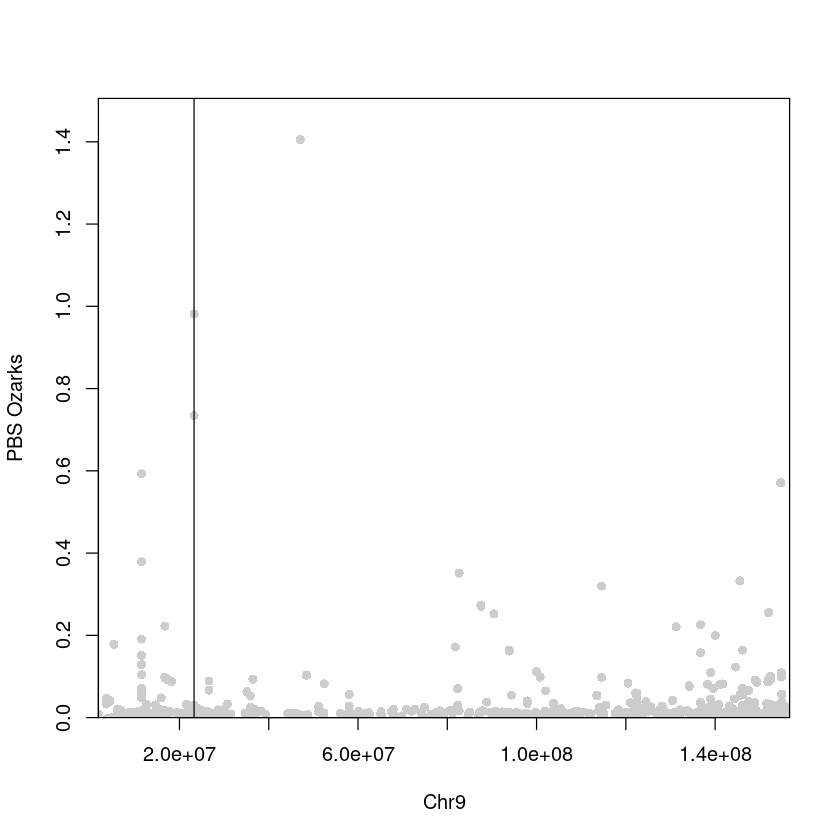

**Question**

Let's look at the results together.

### Run the cell below to take the quiz

```
from jupyterquiz import display_quiz

display_quiz("https://raw.githubusercontent.com/popgenDK/courses/main/current_exercises/selection/quiz/maize_selection.json")
```